# ICU Admissions Term Project, eH705

## 3.1 Viewing a few rows of the recorded dataset

```r
> headTail(ICU) %>% datatable(rownames = TRUE, filter="top", options = list(pageLenght = 10, scrollX=T))%>% formatRound(columns=c(1:17), digits=0)
```

|  | ID | Status | Age | Sex | Race | Service | Cancer | Renal | Infection | CPR | Systolic | HeartRate | Previous | Type | Fracture | PO2 | PH | PCO2 | Bicarbonate | Creatinine | Consciousness |
| --- | --- | --- | --- | --- | --- | --- | --- | --- | --- | --- | --- | --- | --- | --- | --- | --- | --- | --- | --- | --- | --- |
| 1 | 8 | Lived | 27 | Female | White | Medical | No | No | Yes | No | 142 | 88 | No | Emergency | No | No | No | No | No | No | Conscious |
| 2 | 12 | Lived | 59 | Male | White | Medical | No | No | No | No | 112 | 80 | Yes | Emergency | No | No | No | No | No | No | Conscious |
| 3 | 14 | Lived | 77 | Male | White | Surgical | No | No | No | No | 100 | 70 | No | Elective | No | No | No | No | No | No | Conscious |
| 4 | 28 | Lived | 54 | Male | White | Medical | No | No | Yes | No | 142 | 103 | No | Emergency | Yes | No | No | No | No | No | Conscious |
| ... | ... |  | ... |  |  |  |  |  |  |  | ... | ... |  |  |  |  |  |  |  |  |  |
| 197 | 752 | Died | 64 | Male | White | Medical | Yes | No | Yes | No | 80 | 118 | No | Emergency | No | Yes | No | No | No | Yes | Conscious |
| 198 | 789 | Died | 60 | Male | White | Medical | No | No | Yes | No | 56 | 114 | Yes | Emergency | No | No | Yes | No | Yes | No | Conscious |
| 199 | 871 | Died | 60 | Male | Other | Surgical | No | Yes | Yes | No | 130 | 55 | No | Emergency | No | No | No | No | No | No | Deep Stupor |
| 200 | 921 | Died | 50 | Female | Black | Medical | No | No | No | No | 256 | 64 | No | Emergency | No | No | No | No | No | No | Deep Stupor |

## 3.2 Saving new recoded dataset

```r
> # write.csv(ICU, file="ICUAdmissions_recoded.csv", row.names=FALSE)
```

# 4 Data Exploration - Statistical summaries and Graphing of variables

```r
> str(ICU)
```

```
'data.frame':   200 obs. of  21 variables:
 $ ID           : int  8 12 14 28 32 38 40 41 42 50 ...
 $ Status       : Factor w/ 2 levels "Lived","Died": 1 1 1 1 1 1 1 1 1 1 ...
 $ Age          : int  27 59 77 54 87 69 63 30 35 70 ...
 $ Sex          : Factor w/ 2 levels "Male","Female": 2 1 1 1 2 1 1 2 1 2 ...
 $ Race         : Factor w/ 3 levels "White","Black",..: 1 1 1 1 1 1 1 1 2 1 ...
 $ Service      : Factor w/ 2 levels "Medical","Surgical": 1 1 2 1 2 1 2 1 1 2 ...
 $ Cancer       : Factor w/ 2 levels "No","Yes": 1 1 1 1 1 1 1 1 1 2 ...
 $ Renal        : Factor w/ 2 levels "No","Yes": 1 1 1 1 1 1 1 1 1 1 ...
 $ Infection    : Factor w/ 2 levels "No","Yes": 2 1 1 2 2 2 1 1 1 1 ...
 $ CPR          : Factor w/ 2 levels "No","Yes": 1 1 1 1 1 1 1 1 1 1 ...
 $ Systolic     : int  142 112 100 142 110 110 104 144 108 138 ...
 $ HeartRate    : int  88 80 70 103 154 132 66 110 60 103 ...
 $ Previous     : Factor w/ 2 levels "No","Yes": 1 2 1 1 2 1 1 1 1 1 ...
 $ Type         : Factor w/ 2 levels "Elective","Emergency": 2 2 1 2 2 2 1 2 2 1 ...
 $ Fracture     : Factor w/ 2 levels "No","Yes": 1 1 1 2 1 1 1 1 1 1 ...
 $ PO2          : Factor w/ 2 levels "No","Yes": 1 1 1 1 1 2 1 1 1 1 ...
 $ PH           : Factor w/ 2 levels "No","Yes": 1 1 1 1 1 1 1 1 1 1 ...
 $ PCO2         : Factor w/ 2 levels "No","Yes": 1 1 1 1 1 1 1 1 1 1 ...
 $ Bicarbonate  : Factor w/ 2 levels "No","Yes": 1 1 1 1 1 2 1 1 1 1 ...
 $ Creatinine   : Factor w/ 2 levels "No","Yes": 1 1 1 1 1 1 1 1 1 1 ...
 $ Consciousness: Factor w/ 3 levels "Conscious","Deep Stupor",..: 1 1 1 1 1 1 1 1 1 1 ...
```

**Findings** * The following variables were successfully recoded; Status, Sex, Race, Service, Cancer, Renal, Infection, CPR, Previous, Type,Fracture, PCO2,PH, PO2, Bicarbonate, Creatinine, and Consciousness.

## 4.1 Statistical summary of the recoded dataset

```r
> summary(ICU)
```

```
       ID          Status         Age            Sex         Race
 Min.   :  4.0   Lived:160   Min.   :16.00   Male  :124   White:175
 1st Qu.:210.2   Died : 40   1st Qu.:46.75   Female: 76   Black: 15
 Median :412.5               Median :63.00                Other: 10
 Mean   :444.8               Mean   :57.55
 3rd Qu.:671.8               3rd Qu.:72.00
 Max.   :929.0               Max.   :92.00
     Service    Cancer    Renal     Infection  CPR         Systolic
 Medical : 93   No :180   No :181   No :116   No :187   Min.   : 36.0
 Surgical:107   Yes: 20   Yes: 19   Yes: 84   Yes: 13   1st Qu.:110.0
                                                        Median :130.0
                                                        Mean   :132.3
                                                        3rd Qu.:150.0
                                                        Max.   :256.0
   HeartRate      Previous         Type     Fracture   PO2        PH
 Min.   : 39.00   No :170   Elective : 53   No :185   No :184   No :187
 1st Qu.: 80.00   Yes: 30   Emergency:147   Yes: 15   Yes: 16   Yes: 13
 Median : 96.00
 Mean   : 98.92
 3rd Qu.:118.25
 Max.   :192.00
  PCO2     Bicarbonate Creatinine     Consciousness
 No :180   No :185     No :190    Conscious  :185
 Yes: 20   Yes: 15     Yes: 10    Deep Stupor:  5
                                  Coma       : 10
```

## 4.2 Numerical Summary of Int VAriables

```r
> numSummary(ICU[,c("Age", "HeartRate", "Systolic"), drop=FALSE], statistics=c("mean", "sd", "IQR",
+   "quantiles"), quantiles=c(0,.25,.5,.75,1))
```

```
             mean       sd   IQR 0%    25% 50%    75% 100%   n
Age        57.545 20.05465 25.25 16  46.75  63  72.00   92 200
HeartRate  98.925 26.82962 38.25 39  80.00  96 118.25  192 200
Systolic  132.280 32.95210 40.00 36 110.00 130 150.00  256 200
```

## 4.3 Findings

- Age ranges from 16-92 years old with a mean of 57.55 and median of 63
- Systolic blood pressure ranges from 36-256 with a mean of 132.3 and median of 130
- Heart rate ranges from 39-192 beats per minute with a mean of 98.92 and median of 96

# 5 Graphing

## 5.1 Examining the variables distribution

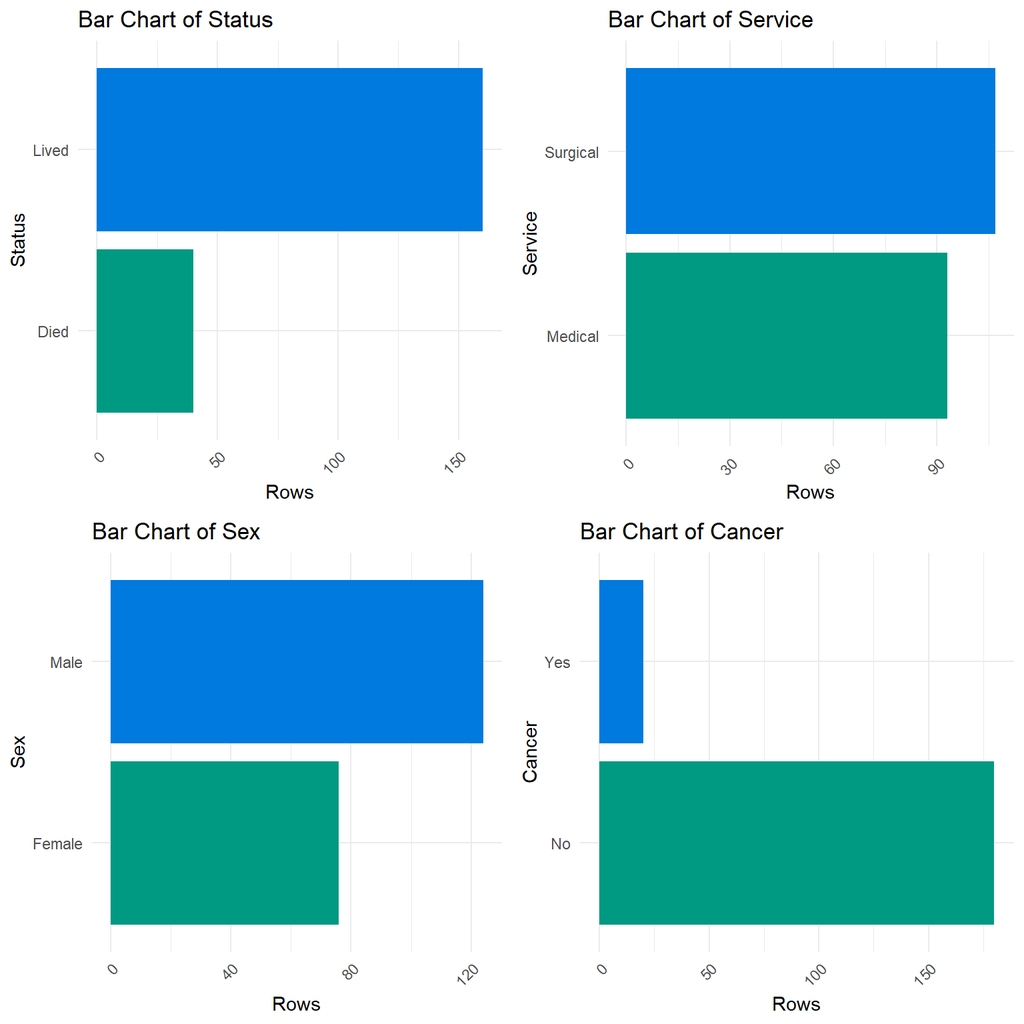

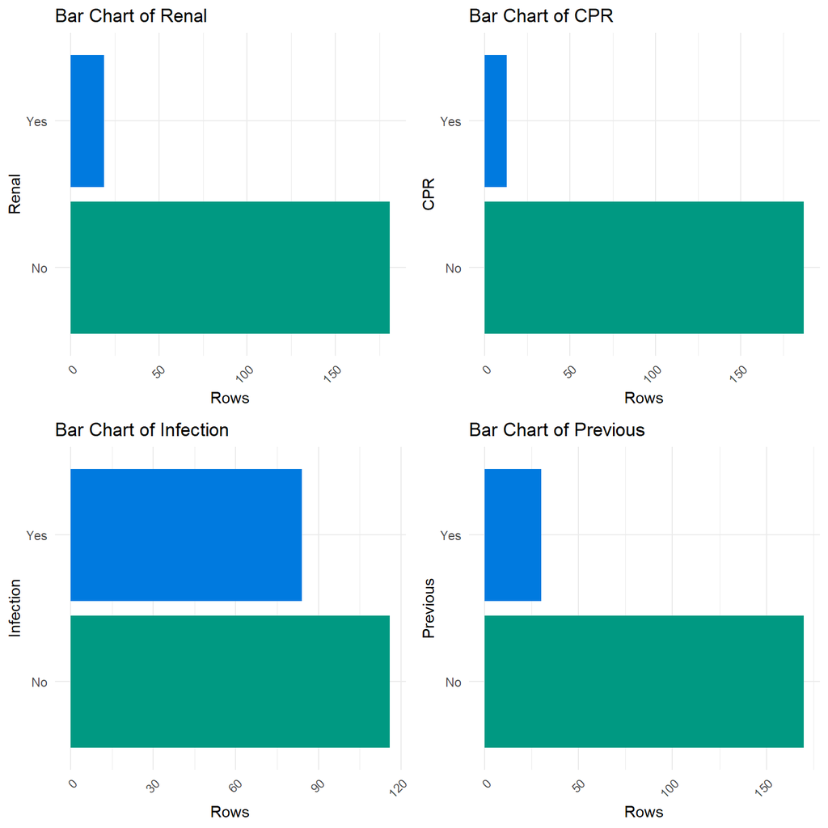

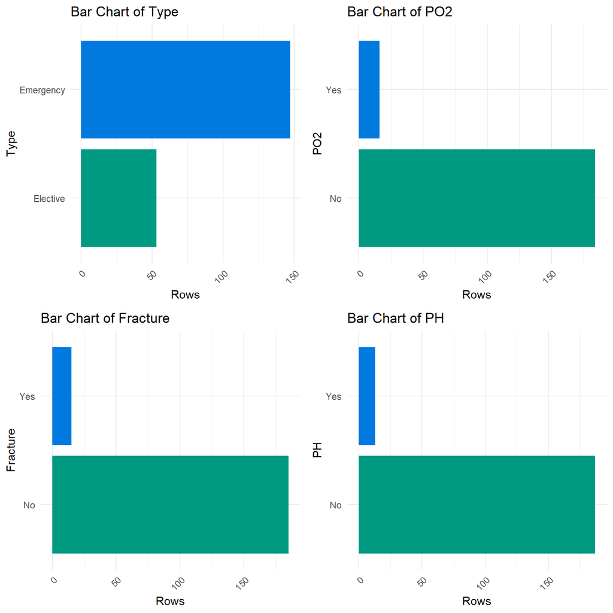

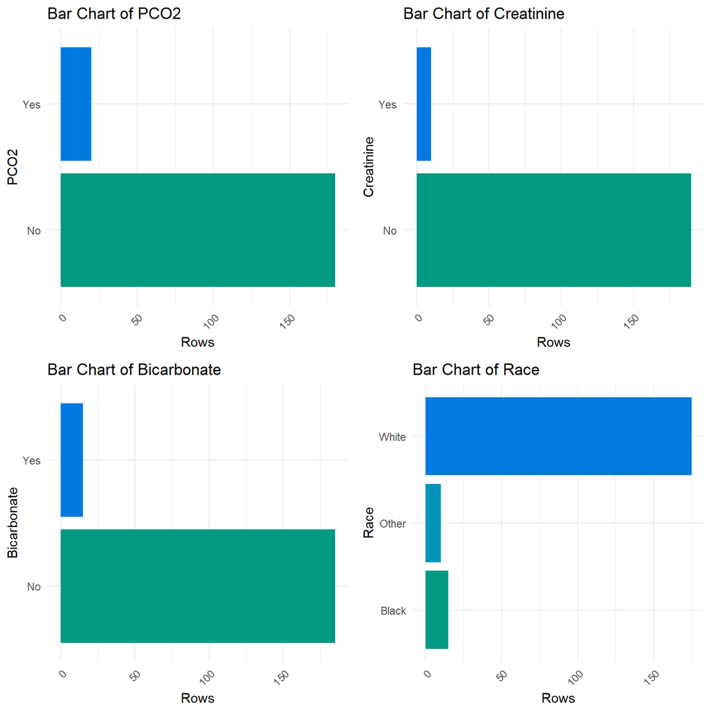

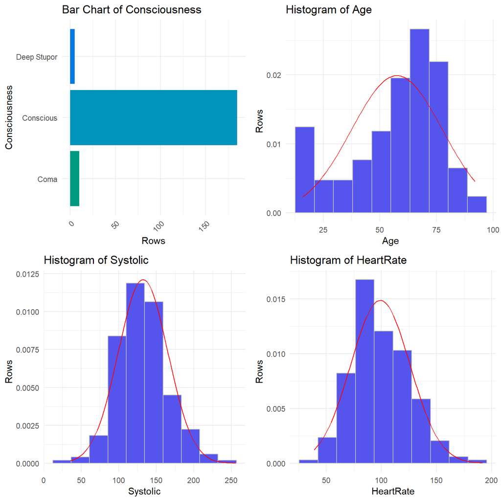

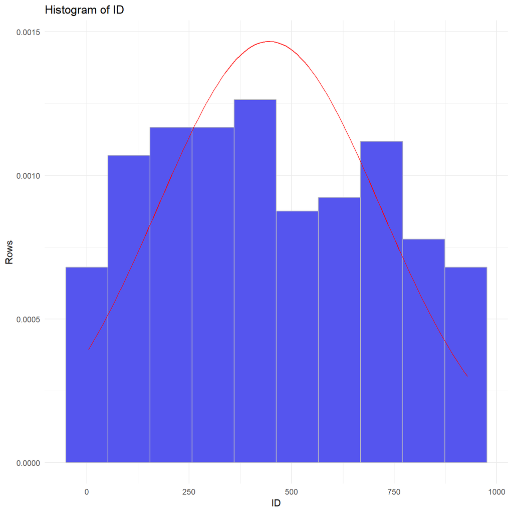

```
   Variable   p_1 p_10   p_25  p_50   p_75  p_90   p_99
1  Systolic 55.92   92    110   130    150   170 212.12
2       Age 16.99   21  46.75    63     72    78     91
3 HeartRate 45.98   65     80    96 118.25 136.1 162.08
4        ID 11.96 81.3 210.25 412.5 671.75 829.8 924.01
```

## 5.2 Distribution of Vital Status by the factor variables

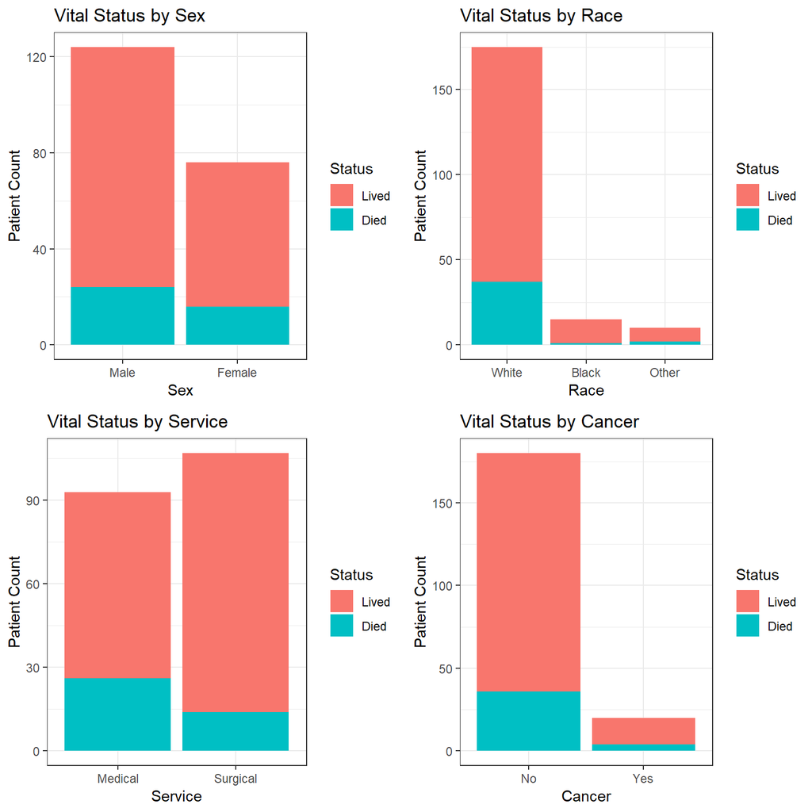

```r
> library(ggplot2)
> f01<-ggplot(ICU, aes(x=Sex, fill = Status)) +
+  theme_bw() +
+  geom_bar() +
+  labs(y = "Patient Count",
+       title = "Vital Status by Sex")
>
> f02<-ggplot(ICU, aes(x=Race, fill = Status)) +
+  theme_bw() +
+  geom_bar() +
+  labs(y = "Patient Count",
+       title = "Vital Status by Race")
> f03<-ggplot(ICU, aes(x=Service, fill = Status)) +
+  theme_bw() +
+  geom_bar() +
+  labs(y = "Patient Count",
+       title = "Vital Status by Service")
>
> f04<-ggplot(ICU, aes(x=Cancer, fill = Status)) +
+  theme_bw() +
+  geom_bar() +
+  labs(y = "Patient Count",
+       title = "Vital Status by Cancer")
>
> library(Rmisc)
> multiplot(f01, f02, f03, f04,  layout=matrix(c(1:4), nrow=2, byrow=TRUE))
```

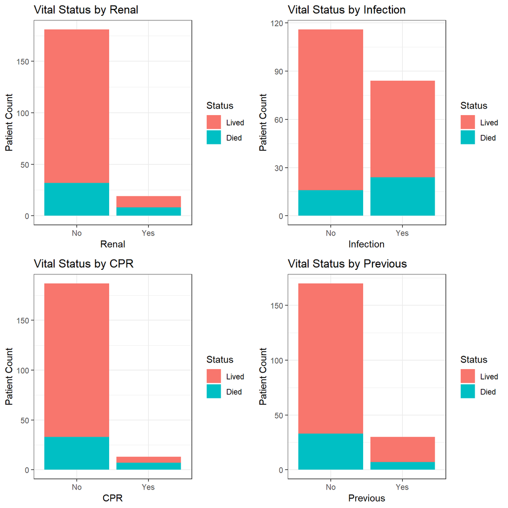

```r
> f05<-ggplot(ICU, aes(x=Renal, fill = Status)) +
+  theme_bw() +
+  geom_bar() +
+  labs(y = "Patient Count",
+       title = "Vital Status by Renal")
>
> f06<-ggplot(ICU, aes(x=Infection, fill = Status)) +
+  theme_bw() +
+  geom_bar() +
+  labs(y = "Patient Count",
+       title = "Vital Status by Infection")
>
> f07<-ggplot(ICU, aes(x=CPR, fill = Status)) +
+  theme_bw() +
+  geom_bar() +
+  labs(y = "Patient Count",
+       title = "Vital Status by CPR")
>
> f08<-ggplot(ICU, aes(x=Previous, fill = Status)) +
+  theme_bw() +
+  geom_bar() +
+  labs(y = "Patient Count",
+       title = "Vital Status by Previous")
>
> library(Rmisc)
> multiplot(f05, f06, f07, f08,  layout=matrix(c(1:4), nrow=2, byrow=TRUE))
```

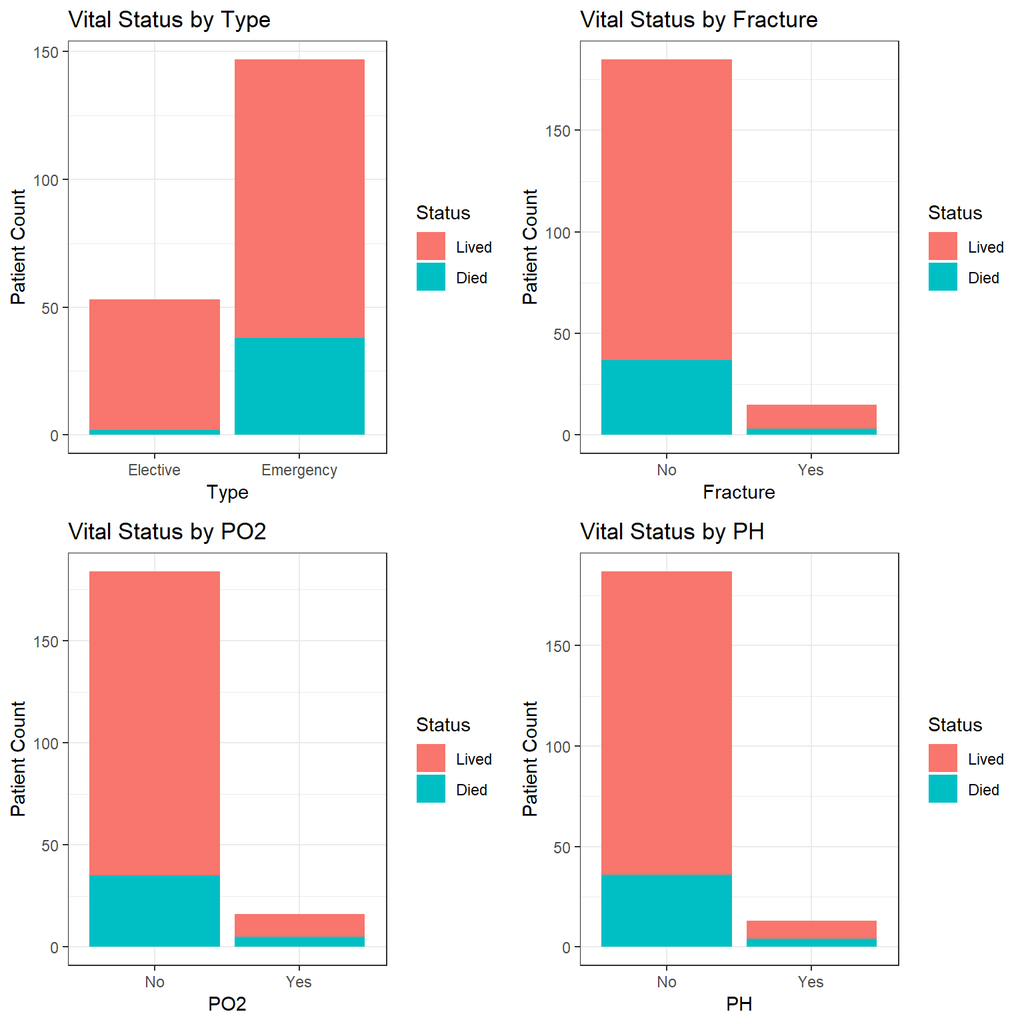

```r
> f09<-ggplot(ICU, aes(x=Type, fill = Status)) +
+  theme_bw() +
+  geom_bar() +
+  labs(y = "Patient Count",
+       title = "Vital Status by Type")
>
> f10<-ggplot(ICU, aes(x=Fracture, fill = Status)) +
+  theme_bw() +
+  geom_bar() +
+  labs(y = "Patient Count",
+       title = "Vital Status by Fracture")
>
> f11<-ggplot(ICU, aes(x=PO2, fill = Status)) +
+  theme_bw() +
+  geom_bar() +
+  labs(y = "Patient Count",
+       title = "Vital Status by PO2")
>
> f12<-ggplot(ICU, aes(x=PH, fill = Status)) +
+  theme_bw() +
+  geom_bar() +
+  labs(y = "Patient Count",
+       title = "Vital Status by PH")
>
> library(Rmisc)
> multiplot(f09, f10, f11, f12,  layout=matrix(c(1:4), nrow=2, byrow=TRUE))
```

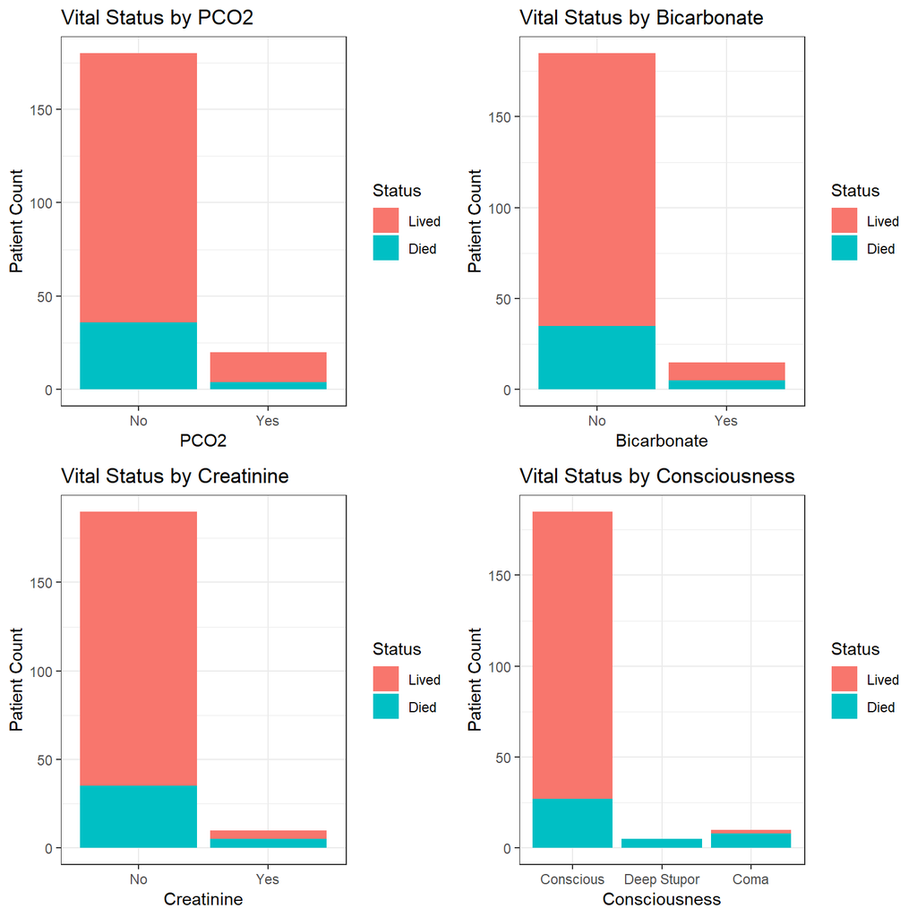

```r
> f13<-ggplot(ICU, aes(x=PCO2, fill = Status)) +
+  theme_bw() +
+  geom_bar() +
+  labs(y = "Patient Count",
+       title = "Vital Status by PCO2")
>
> f14<-ggplot(ICU, aes(x=Bicarbonate, fill = Status)) +
+  theme_bw() +
+  geom_bar() +
+  labs(y = "Patient Count",
+       title = "Vital Status by Bicarbonate")
>
> f15<-ggplot(ICU, aes(x=Creatinine, fill = Status)) +
+  theme_bw() +
+  geom_bar() +
+  labs(y = "Patient Count",
+       title = "Vital Status by Creatinine")
>
> f16<-ggplot(ICU, aes(x=Consciousness, fill = Status)) +
+  theme_bw() +
+  geom_bar() +
+  labs(y = "Patient Count",
+       title = "Vital Status by Consciousness")
>
>
> library(Rmisc)
> multiplot(f13, f14, f15, f16, layout=matrix(c(1:4), nrow=2, byrow=TRUE))
```

## 5.3 Plotting the density Distribution of the Numeric Variable

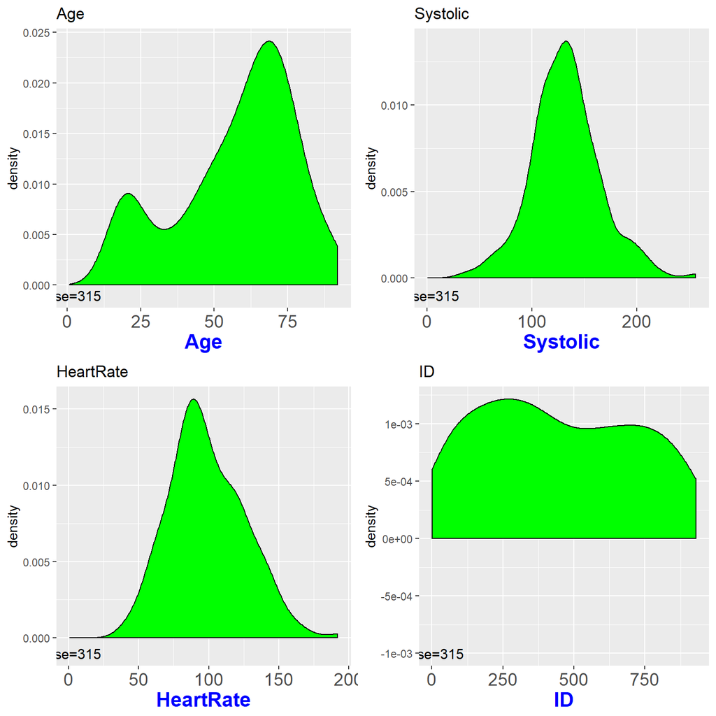

```r
> d01 <- ggplot(ICU, aes(x=Age)) +
+  geom_density(fill="green") +
+  ggtitle("Age") +
+  theme(axis.title.x=element_text(size=16, face="bold", colour="blue")) +
+  theme(axis.text.x=element_text(size=14 )) +
+  annotate("text", x=0.8, y=-0.001, label="Base=315",  size=4)
>
> d02 <- ggplot(ICU, aes(x=Systolic)) +
+  geom_density(fill="green") +
+  ggtitle("Systolic") +
+  theme(axis.title.x=element_text(size=16, face="bold", colour="blue")) +
+  theme(axis.text.x=element_text(size=14 )) +
+  annotate("text", x=0.8, y=-0.001, label="Base=315",  size=4)
>
> d03 <- ggplot(ICU, aes(x=HeartRate)) +
+  geom_density(fill="green") +
+  ggtitle("HeartRate") +
+  theme(axis.title.x=element_text(size=16, face="bold", colour="blue")) +
+  theme(axis.text.x=element_text(size=14 )) +
+  annotate("text", x=0.8, y=-0.001, label="Base=315",  size=4)
>
> d04 <- ggplot(ICU, aes(x=ID)) +
+  geom_density(fill="green") +
+  ggtitle("ID") +
+  theme(axis.title.x=element_text(size=16, face="bold", colour="blue")) +
+  theme(axis.text.x=element_text(size=14 )) +
+  annotate("text", x=0.8, y=-0.001, label="Base=315",  size=4)
>
> multiplot(d01, d02, d03, d04, layout=matrix(c(1:4), nrow=2, byrow=TRUE))
```